# AAE722_HW2_Eunjee

## Homework 2

Chapter 4: Questions 14 and 15

Chapter 5: Questions 8 and 9

Chapter 6: Questions 1 and 2

```python
import numpy as np
import pandas as pd
from matplotlib.pyplot import subplots
import matplotlib.pyplot as plt
import statsmodels.api as sm
import ISLP
from ISLP import load_data
from ISLP.models import (ModelSpec as MS,summarize)
import seaborn as sns
from sklearn.discriminant_analysis import \
     (LinearDiscriminantAnalysis as LDA,
      QuadraticDiscriminantAnalysis as QDA)
from sklearn.naive_bayes import GaussianNB
from sklearn.neighbors import KNeighborsClassifier
from sklearn.preprocessing import StandardScaler
from sklearn.model_selection import train_test_split
from sklearn.linear_model import LogisticRegression
from sklearn.metrics import accuracy_score
```

# Chapter 4 #14

```python
# load data
Auto=load_data("Auto")
Auto.head()
```

| name | mpg | cylinders | displacement | horsepower | weight | acceleration | year | origin |
| --- | --- | --- | --- | --- | --- | --- | --- | --- |
| chevrolet chevelle malibu | 18.0 | 8 | 307.0 | 130 | 3504 | 12.0 | 70 | 1 |
| buick skylark 320 | 15.0 | 8 | 350.0 | 165 | 3693 | 11.5 | 70 | 1 |
| plymouth satellite | 18.0 | 8 | 318.0 | 150 | 3436 | 11.0 | 70 | 1 |
| amc rebel sst | 16.0 | 8 | 304.0 | 150 | 3433 | 12.0 | 70 | 1 |
| ford torino | 17.0 | 8 | 302.0 | 140 | 3449 | 10.5 | 70 | 1 |

```python
# 4.14 (a)
mpg01=np.where(Auto["mpg"]>Auto["mpg"].median(),1,0)
Auto['mpg01']=mpg01
```

```python
# 4.14 (b)
Auto.corr(numeric_only=True)
```

|  | mpg | cylinders | displacement | horsepower | weight | acceleration | year | origin | mpg01 |
| --- | --- | --- | --- | --- | --- | --- | --- | --- | --- |
| mpg | 1.000000 | -0.777618 | -0.805127 | -0.778427 | -0.832244 | 0.423329 | 0.580541 | 0.565209 | 0.836939 |
| cylinders | -0.777618 | 1.000000 | 0.950823 | 0.842983 | 0.897527 | -0.504683 | -0.345647 | -0.568932 | -0.759194 |
| displacement | -0.805127 | 0.950823 | 1.000000 | 0.897257 | 0.932994 | -0.543800 | -0.369855 | -0.614535 | -0.753477 |
| horsepower | -0.778427 | 0.842983 | 0.897257 | 1.000000 | 0.864538 | -0.689196 | -0.416361 | -0.455171 | -0.667053 |
| weight | -0.832244 | 0.897527 | 0.932994 | 0.864538 | 1.000000 | -0.416839 | -0.309120 | -0.585005 | -0.757757 |
| acceleration | 0.423329 | -0.504683 | -0.543800 | -0.689196 | -0.416839 | 1.000000 | 0.290316 | 0.212746 | 0.346822 |
| year | 0.580541 | -0.345647 | -0.369855 | -0.416361 | -0.309120 | 0.290316 | 1.000000 | 0.181528 | 0.429904 |
| origin | 0.565209 | -0.568932 | -0.614535 | -0.455171 | -0.585005 | 0.212746 | 0.181528 | 1.000000 | 0.513698 |
| mpg01 | 0.836939 | -0.759194 | -0.753477 | -0.667053 | -0.757757 | 0.346822 | 0.429904 | 0.513698 | 1.000000 |

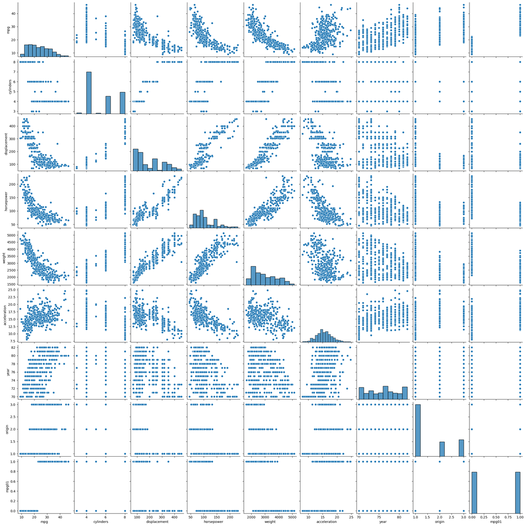

```python
sns.pairplot(Auto);
```

From the graph and the correlation matrix we can conclude that there may be a significant correlation among "mpg01", "displacement", "weight" and "cylinders".

```python
# 4.14 (c)
x=Auto[['weight','displacement','cylinders']].values
#the values attribute is used to convert x from a dataframe object to an array
y=Auto['mpg01'].values
(X_train,X_test,y_train,y_test) = train_test_split(x,y,random_state=1)
```

```python
# 4.14 (d)
lda=LDA(store_covariance=True)
lda.fit(X_train, y_train)
```

```
LinearDiscriminantAnalysis(store_covariance=True)
```

```python
lda_pred=lda.predict(X_test)
ISLP.confusion_table(lda_pred,y_test)
```

| Truth Predicted | 0 | 1 |
| --- | --- | --- |
| 0 | 49 | 2 |
| 1 | 5 | 42 |

```python
(49+42)/(49+42+5+2)
```

```
0.9285714285714286
```

```python
LDA_test_err=1-accuracy_score(y_test, lda.predict(X_test))
LDA_test_err
```

```
0.0714285714285714
```

The test error for the LDA model is about 7%.

```python
# 4.14 (e)
qda=QDA(store_covariance=True)
qda.fit(X_train, y_train)
```

```
QuadraticDiscriminantAnalysis(store_covariance=True)
```

```python
qda_pred=qda.predict(X_test)
QDA_test_err=1-accuracy_score(y_test, qda.predict(X_test))
QDA_test_err
```

```
0.061224489795918324
```

```python
# 4.14 (f)
lr=LogisticRegression()
result=lr.fit(X_train,y_train)
lr_test_error=1-accuracy_score(y_test, lr.predict(X_test))
lr_test_error
```

```
0.061224489795918324
```

The test error for the logistic regression model is about 6%.

```python
# 4.14 (g)
NB = GaussianNB()
NB.fit(X_train, y_train)
```

```
GaussianNB()
```

```python
NB_pred=NB.predict(X_test)
NB_test_error=1-accuracy_score(y_test, NB_pred)
NB_test_error
```

```
0.0714285714285714
```

The test error for Naive Bayes model is about 7%.

```
K=  1, accuracy = 0.8469
K=  2, accuracy = 0.8776
K=  3, accuracy = 0.8673
K=  4, accuracy = 0.8776
K=  5, accuracy = 0.8571
K=  6, accuracy = 0.8878
K=  7, accuracy = 0.8776
K=  8, accuracy = 0.9082
K=  9, accuracy = 0.8980
K= 10, accuracy = 0.8878
K= 11, accuracy = 0.9082
K= 12, accuracy = 0.9082
K= 13, accuracy = 0.9184
K= 14, accuracy = 0.9082
K= 15, accuracy = 0.8980
K= 16, accuracy = 0.8980
K= 17, accuracy = 0.8878
K= 18, accuracy = 0.9184
K= 19, accuracy = 0.9082
K= 20, accuracy = 0.9184
K= 21, accuracy = 0.9082
K= 22, accuracy = 0.9082
K= 23, accuracy = 0.9082
K= 24, accuracy = 0.9184
K= 25, accuracy = 0.9082
K= 26, accuracy = 0.9184
K= 27, accuracy = 0.9184
K= 28, accuracy = 0.9184
K= 29, accuracy = 0.9184
K= 30, accuracy = 0.9184
K= 31, accuracy = 0.9184
K= 32, accuracy = 0.9184
K= 33, accuracy = 0.9082
K= 34, accuracy = 0.9082
K= 35, accuracy = 0.8980
K= 36, accuracy = 0.9082
K= 37, accuracy = 0.8980
K= 38, accuracy = 0.8980
K= 39, accuracy = 0.8980
K= 40, accuracy = 0.8980
```

[output cut: 45 more lines]

```
K= 86, accuracy = 0.8980
K= 87, accuracy = 0.8980
K= 88, accuracy = 0.8980
K= 89, accuracy = 0.8878
K= 90, accuracy = 0.8878
K= 91, accuracy = 0.8878
K= 92, accuracy = 0.8980
K= 93, accuracy = 0.8878
K= 94, accuracy = 0.8878
K= 95, accuracy = 0.8878
K= 96, accuracy = 0.8878
K= 97, accuracy = 0.8878
K= 98, accuracy = 0.8878
K= 99, accuracy = 0.8878
K=100, accuracy = 0.8980
```

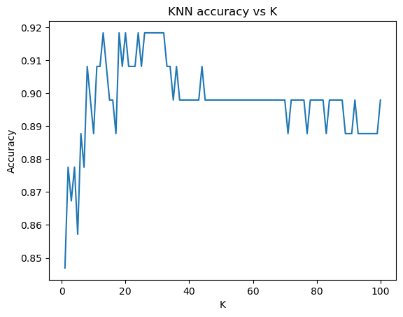

```
Best K:  13
```

```python
# 4.14 (h)
for k in range(1,101):
    knn = KNeighborsClassifier(n_neighbors=k)
    knn.fit(X_train, y_train)
    acc = accuracy_score(y_test, knn.predict(X_test))
    print('K={:3}, accuracy = {:.4f}'.format(k, acc))
# plot this
fig, ax = plt.subplots()
ax.plot(range(1,101), [accuracy_score(y_test, KNeighborsClassifier(n_neighbors=k).fit(X_train, y_train).predict(X_test)) for k in range(1,101)])
ax.set_xlabel('K')
ax.set_ylabel('Accuracy')
ax.set_title('KNN accuracy vs K')
plt.show()
# find the best K
best_k = np.argmax([accuracy_score(y_test, KNeighborsClassifier(n_neighbors=k).fit(X_train, y_train).predict(X_test)) for k in range(1,101)])+1
print('Best K: ', best_k)
```

The value $K=13$ seems the best.

# Chapter 4 #15

```python
# 4.15 (a)
def Power():
    print(2**3)
# 4.15 (b)
def Power2(x,a):
    print(x**a)
# 4.15 (c)
Power2(10,3)
Power2(8,17)
Power2(131,3)
```

```
1000
2251799813685248
2248091
```

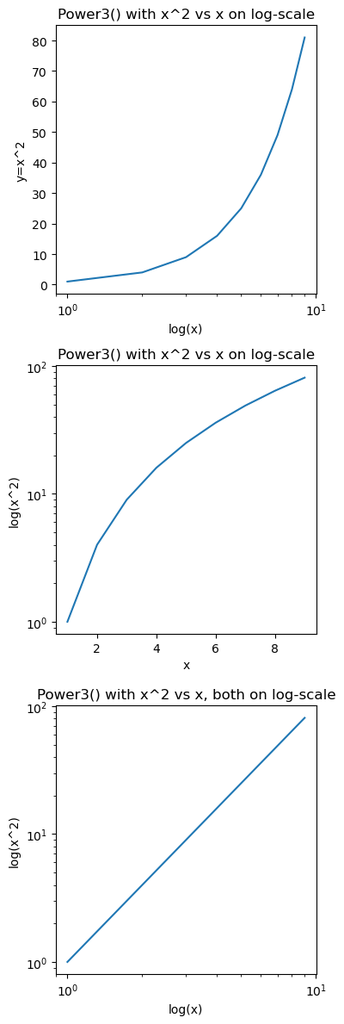

```python
# 4.15 (d)
def Power3(x,a):
    return x**a
# 4.15 (e)
x = np.arange(1,10)
y = Power3(x,2)
fig, ax = plt.subplots(3,figsize=(4,12))
ax[0].set_xscale('log')
ax[0].set_title('Power3() with x^2 vs x on log-scale')
ax[0].set_xlabel('log(x)')
ax[0].set_ylabel('y=x^2')
ax[0].plot(x,y);

ax[1].set_yscale('log')
ax[1].set_title('Power3() with x^2 vs x on log-scale')
ax[1].set_xlabel('x')
ax[1].set_ylabel('log(x^2)')
ax[1].plot(x,y);

ax[2].set_xscale('log')
ax[2].set_yscale('log')
ax[2].set_title('Power3() with x^2 vs x, both on log-scale')
ax[2].set_xlabel('log(x)')
ax[2].set_ylabel('log(x^2)')
ax[2].plot(x,y);

plt.tight_layout()
plt.show()
```

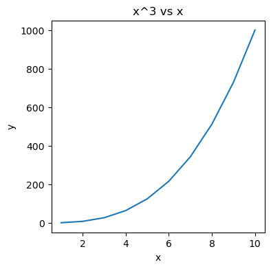

```python
# 4.15 (f)
def PlotPower(x,a,log=''):
    y = Power3(x,a)
    fig, ax = plt.subplots(figsize=(4,4))
    ax.set_xlabel('x')
    ax.set_ylabel('y')
    ax.set_title('x^%.0f vs x' %a)
    if log=='xy':
        ax.set_xscale('log')
        ax.set_yscale('log')
        ax.set_title('x^%.0f vs x, both on log-scale'%a)
        ax.set_xlabel('log(x)')
        ax.set_ylabel('log(x^%.0f)'%a)
    if log=='x':
        ax.set_xscale('log')
        ax.set_title('x^%.0f vs log(x)'%a)
        ax.set_xlabel('log(x)')
        ax.set_ylabel('x^%.0f'%a)
    if log=='y':
        ax.set_yscale('log')
        ax.set_title('log(x^%.0f) vs x'%a)
        ax.set_xlabel('x')
        ax.set_ylabel('log(x^%.0f)'%a)
    ax.plot(x,y);
    plt.show()
PlotPower(np.arange(1,11),3)
```

# Chapter 5 #8

```python
!pip install scikit-learn
```

```python
import pandas as pd
import numpy as np
import math
import matplotlib.pyplot as plt
from sklearn.model_selection import LeaveOneOut
from sklearn.linear_model import LinearRegression
from sklearn.preprocessing import PolynomialFeatures
from sklearn.pipeline import Pipeline
import statsmodels.api as sm  # To fit models using least squares
```

```python
# 5.8(a)
np.random.seed(1)  # Random numbers generated by Python are different from those generated by R, as mentioned in Exercise 3.11

y = np.random.normal(size=100)  # By default np.random.normal considers a standard normal, so we just have to define the size
x = np.random.normal(size=100)
epsilon = np.random.normal(size=100)

y = x - 2 * x**2 + epsilon
```

n = number of observations = 100

p = number of predictors = 2 (X and X^2)

Model in equation form: $$y = x - 2 * x**2 + \epsilon$$

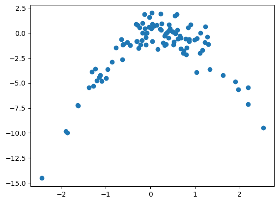

```python
#5.8.(b)
plt.scatter(x, y)
```

```python
# 5.8.(c)
# new random seed
np.random.seed(2)
# compute LOOCV errors
loo = LeaveOneOut()
# organize data into a dataframe
df = pd.DataFrame({'x': x, 'y': y})
# compute the LOOCV errors for the four models
miminum_degree = 1
maximum_degree = 4
scores = []

for i in range(miminum_degree, maximum_degree + 1):
    polynomial_features = PolynomialFeatures(degree=i)
    linear_regression = LinearRegression()
    model = Pipeline([("polynomial_features", polynomial_features), ("linear_regression", linear_regression)])
    errors = []
    for train_index, test_index in loo.split(df):
        train = df.iloc[train_index]
        test = df.iloc[test_index]
        model.fit(train[['x']], train['y'])
        errors.append((model.predict(test[['x']]) - test['y'])**2)
    print(f'model {i} - error : {np.mean(errors)}')
    scores.append(np.mean(errors))
```

```
model 1 - error : 8.292211622874765
model 2 - error : 1.0170958070339804
model 3 - error : 1.0465534563296683
model 4 - error : 1.0574926712115138
```

```python
# 5.8.(d)
# set new random seed
np.random.seed(3)
# compute LOOCV errors
loo = LeaveOneOut()
# organize data into a dataframe
df = pd.DataFrame({'x': x, 'y': y})
# compute the LOOCV errors for the four models
miminum_degree = 1
maximum_degree = 4
scores = []

for i in range(miminum_degree, maximum_degree + 1):
    polynomial_features = PolynomialFeatures(degree=i)
    linear_regression = LinearRegression()
    model = Pipeline([("polynomial_features", polynomial_features), ("linear_regression", linear_regression)])
    errors = []
    for train_index, test_index in loo.split(df):
        train = df.iloc[train_index]
        test = df.iloc[test_index]
        model.fit(train[['x']], train['y'])
        errors.append((model.predict(test[['x']]) - test['y'])**2)
    print(f'model {i} - error : {np.mean(errors)}')
    scores.append(np.mean(errors))
```

```
model 1 - error : 8.292211622874765
model 2 - error : 1.0170958070339804
model 3 - error : 1.0465534563296683
model 4 - error : 1.0574926712115138
```

The results should be the same, as there is no randomness acting in the cross-validation processes.

5.8.(e)

The model with the smallest LOOCV error was model 2. This was expected since the scatter plot above a demonstraited quadractic shape.

```python
# 5.8.(f) print ols results.summary for each model
for i in range(miminum_degree, maximum_degree + 1):
    polynomial_features = PolynomialFeatures(degree=i)
    linear_regression = LinearRegression()
    model = Pipeline([("polynomial_features", polynomial_features), ("linear_regression", linear_regression)])
    model.fit(df[['x']], df['y'])
    X = polynomial_features.fit_transform(df[['x']])
    y = df['y']
    model = sm.OLS(y, X)
    results = model.fit()
    print(results.summary())
```

```
                            OLS Regression Results
==============================================================================
Dep. Variable:                      y   R-squared:                       0.088
Model:                            OLS   Adj. R-squared:                  0.079
Method:                 Least Squares   F-statistic:                     9.460
Date:                Sat, 12 Oct 2024   Prob (F-statistic):            0.00272
Time:                        12:18:17   Log-Likelihood:                -242.69
No. Observations:                 100   AIC:                             489.4
Df Residuals:                      98   BIC:                             494.6
Df Model:                           1
Covariance Type:            nonrobust
==============================================================================
                 coef    std err          t      P>|t|      [0.025      0.975]
------------------------------------------------------------------------------
const         -1.7609      0.280     -6.278      0.000      -2.317      -1.204
x1             0.9134      0.297      3.076      0.003       0.324       1.503
==============================================================================
Omnibus:                       40.887   Durbin-Watson:                   1.957
Prob(Omnibus):                  0.000   Jarque-Bera (JB):               83.786
Skew:                          -1.645   Prob(JB):                     6.40e-19
Kurtosis:                       6.048   Cond. No.                         1.19
==============================================================================

Notes:
[1] Standard Errors assume that the covariance matrix of the errors is correctly specified.
                            OLS Regression Results
==============================================================================
Dep. Variable:                      y   R-squared:                       0.882
Model:                            OLS   Adj. R-squared:                  0.880
Method:                 Least Squares   F-statistic:                     362.9
Date:                Sat, 12 Oct 2024   Prob (F-statistic):           9.26e-46
Time:                        12:18:17   Log-Likelihood:                -140.40
No. Observations:                 100   AIC:                             286.8
Df Residuals:                      97   BIC:                             294.6
Df Model:                           2
Covariance Type:            nonrobust
==============================================================================
                 coef    std err          t      P>|t|      [0.025      0.975]
------------------------------------------------------------------------------
const         -0.0216      0.122     -0.177      0.860      -0.264       0.221
```

[output cut: 51 more lines]

```
------------------------------------------------------------------------------
const          0.0866      0.144      0.600      0.550      -0.200       0.373
x1             1.0834      0.189      5.724      0.000       0.708       1.459
x2            -2.2455      0.214    -10.505      0.000      -2.670      -1.821
x3             0.0436      0.058      0.755      0.452      -0.071       0.158
x4             0.0482      0.043      1.132      0.260      -0.036       0.133
==============================================================================
Omnibus:                        0.102   Durbin-Watson:                   2.214
Prob(Omnibus):                  0.950   Jarque-Bera (JB):                0.117
Skew:                           0.069   Prob(JB):                        0.943
Kurtosis:                       2.906   Cond. No.                         17.5
==============================================================================

Notes:
[1] Standard Errors assume that the covariance matrix of the errors is correctly specified.
```

We focus on the t-statistics and the coefficients.

In model 2, both x1 and x2 have large t-statistics.

In model 3, x2 has the largest t-statistics followed by x1 and x3.

In model 4, x2 has the largest t-statistics, follwed by x1, x4, and x3.

For these, we could conclude that x2 and x1 are the most relevent variables, which is parallel to our observation from the cross-validation results that model 2 has the smallest errors.

# Chapter 5 #9

```python
import numpy as np
import pandas as pd
Boston=load_data('Boston')
```

```python
# 5.9.(a)
mu_hat=Boston['medv'].mean()
mu_hat
```

```
22.532806324110677
```

The population mean estimate for "medv" is 22.53

```python
# 5.9.(b)
SE_mu_hat=Boston['medv'].std()/(Boston.shape[0])**0.5
SE_mu_hat
```

```
0.40886114749753505
```

The estimated standard deviation is 0.41.

```python
Boston['medv'].index
```

```
RangeIndex(start=0, stop=506, step=1)
```

```python
# 5.9.(c)
means=[]
for _ in range(1000):
    means.append(Boston['medv'].sample(n=Boston.shape[0],replace=True,random_state=None).mean())
boot_std=np.std(means)
boot_std
```

```
0.44208504016823746
```

The answer is fairly close the one obtained in (b). This assures that we can compute the SE of the sample mean by dividing the sample standard deviation by the square root of the number of observations.

```python
# 5.9.(d)
print('The 95% confidence interval for the mean of medv is', [mu_hat-2*boot_std,mu_hat+2*boot_std])
```

```
The 95% confidence interval for the mean of medv is [21.648636243774202, 23.41697640444715]
```

```python
# 5.9.(e)
mu_med=Boston['medv'].median()
mu_med
```

```
21.2
```

The estimate for the median value of 'medv' in the population is 21.2.

```python
# 5.9.(f)
medians=[]
for _ in range(10000):
    medians.append(Boston['medv'].sample(n=Boston.shape[0],replace=True).median())
boot_med_std=np.std(medians)
boot_med_std
```

```
0.38008527345846976
```

The standard error of the median is less than the standard error of the mean. This a sign of non normality of the distribution of feature 'medv'

```python
mu_01=np.percentile(Boston['medv'],10)
mu_01
```

```
12.75
```

```python
# 5.9.(g)
percentiles=[]
for _ in range(5000):
    sample=Boston['medv'].sample(n=Boston.shape[0],replace=True)
    percentiles.append(np.percentile(sample,10))
boot_mu01_std=np.std(percentiles)
boot_mu01_std
```

```
0.5017796160666552
```

The standard error is relatively small to the tenth percentile.

# Chapter 6 #1

# 6.1(a)

The best subset model finds the model with $k$ predictors which would have the lowest training error, searching all the possible combinations of $p\choose k$. Forward and backward stepsize methods pick from $p-k$ models. Thus, if any earlir step chooses any variable not chosen by the best model, then the training error would increase compared to that of the best model.

# 6.1(b)

For the test data, it depends on the method of validation, training set, and test set. This is because the best subset method could overfit the training data. Therefore, this time, the other two methods, the forward and backward stepwize method my end up choosing $k$ predictors with larger training error that decreases the risk of overfitting. However, this definitely rely on the ground truth, and how close each model is to the true model.

# 6.1(c)

i. True: This is because the $k+1$ forward stepwise method picks one more predictors after picking $k$ predictors.\ ii. True: This is because the $k$ backward stepwise method removes one more predictors after deleting $n-k-1$ predictors, which is where the $k+1$ backward stepwise method stops. \ iii. False: Consider this counter-example. $p=4$ and $k=2$. Assume that the backward selection selects $x_1$ and $x_2$. Forward selection with $3$ predictors can select $x_2$, $x_3$, and $x_4$ given that including $x_1$ does not decrease the error than including other variables. \ iv. False: Consider this counter-example. $p=4$ and $k=2$. Assume that the forward selection selects $x_1$ and $x_2$. Backward selection with $3$ predictors can select $x_2$, $x_3$, and $x_4$ given that discarding $x_1$ increase the error the least, compared to discarding other variables.\ v. False: There is no such guarantee that the best model with $k$ predictors are a subset of the best model with $k+1$ predictors, because there can be interaction between different predictors. For example, there can be two predictors that decrease the error much only when these two predictors are included together. In this case, these two variables might be included in the best subset selection with $k+1$ model, yet not included in the best subset wtih $k$ predictors. Then, there should be at least one predictor include in the $k$ predictor version, which is not included in the $k+1$ version.

# Chapter 6 # 2

# 6.2(a)

(iii) As Lasso can decrease the number of predictors, it is less flexible. Also, Lasso method increase bias for the sake of decrease in variance(sensitivity).

# 6.2(b)

(iii) As Ridge can decrease the number of predictors, it is less flexible. Also, Ridge method increase bias for the sake of decrease in variance(sensitivity).

# 6.2(c)

(ii) Non-linear methods are more flexible in that they could capture the non-linear relationships between predictors and the outcome variable. Also, non-linear models reduce bias with the expence of higher variance, as they are more likely to pick up the noise of the training data.